# Day-5 Options In Visualization and Statistics

2022-06-23 08:00:00

```r
library(ggplot2)
```

# Options In Visualization

## col설정해주기

- +scale_color_manual( labels = c(“칼럼명”) values = c(“색”) )

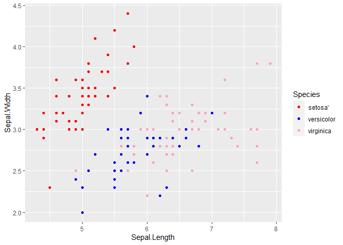

```r
ggplot(data=iris, aes(x=Sepal.Length, y=Sepal.Width,
                      col=Species)) +
  geom_point()  +
  scale_color_manual(
    labels = c("setosa'", "versicolor", "virginica"),
    values = c("red", "blue", "#F9A2C3")
  )
```

## 테마설정해주기

- +theme_종류

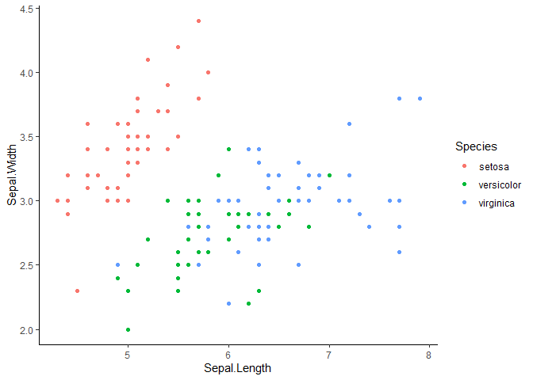

```r
ggplot(data=iris, aes(x=Sepal.Length, y=Sepal.Width,
                      col=Species)) +
  geom_point()  +
  theme_classic()
```

# Statistics

## 기술통계

- 평균, 최솟값, 최댓값, 중간값

## 추론통계(Inferential Statistics)

- 변수 간의 관계를 파악 / 새로운 사실들을 추정
  - 평균 차이 검정
    - 수치데이터
    - 가설검정 : 그룹들 간의 평균의 차이를 검정
  - 교차분석(=빈도분석)(문자열)
    - 범주데이터
    - 가설검정 : 각 범주별 빈도를 활용해서 관계성을 검정 -상관관계분석
    - 수치데이터
    - 두 변수간의 상관관계가 있느냐
    - -1<= r <= 1
    - 그래프를 그렸을때 우상향 : 양의관계, 우하향 : 음의관계
    - 0에 수렴할수록 상관관계가 없다.
    - -1, 1에 수렴할수록 상관관계가 높다.
  - 단순회귀분석 -수치데이터
    - y= ax + b
      - b= 상수항
      - 가설검정 : x값(독립변수)이 y값(종속변수)에 영향을 주느냐

## Hypothesis

### 귀무가설

- 두 그룹간의 평균 차이가 없다.

### 대립가설

- 두 그룹간의 평균 차이가 있다.

### 유의수준

- 허용할 수 있는 오류(예외) 범위
- p-value(p)
- 가설 검정에서 인정하는 유의 수준
- 5%, 1%, 0.1% 또는 10%
- 오차범위내에 있다 <-평균차이가 없다 <- 다음에 했을 때 바뀔 가능성이 있다
- 오차범위밖에 있다 <-평균차이가 있다 <- 몇번을 해도 똑같다

### t.test (모수검정)

- 어떻게 데이터를 입력하는지 확인
- p-value 위주로 확인하면된다
  - 0.05 이상 : 귀무가설, 0.05이내 : 대립가설

```r
mpg1 <- read.csv("data/mpg1.csv", stringsAsFactors = FALSE)
```

- 시각화

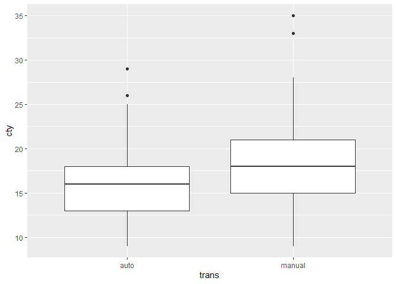

```r
library(ggplot2)
ggplot(mpg1, aes(x = trans, y = cty)) +
  geom_boxplot()
```

- t.test 검정
- 귀무가설 : auto와 manual의 cty 평균은 차이가 없다.
- 대립가설 : auto와 manual의 cty 평균은 차이가 있다.

```r
t.test(data = mpg1, cty ~ trans)
```

```
##
##  Welch Two Sample t-test
##
## data:  cty by trans
## t = -4.5375, df = 132.32, p-value = 1.263e-05
## alternative hypothesis: true difference in means between group auto and group manual is not equal to 0
## 95 percent confidence interval:
##  -3.887311 -1.527033
## sample estimates:
##   mean in group auto mean in group manual
##             15.96815             18.67532
```

```r
                  # (종속변수 ~ 독립변수)
```

- 두 그룹의 평균 차이 검정
  - 사전 필수 검증
  - 등분산 검정 : 두 그룹간의 분산 정도를 비교
    - 두 그룹간의 분산이 비슷하면 –> t.test(모수 검정)
    - 두 그룹간의 분산이 다르면 –> 비모수 검정
    - 귀무가설 : 두 그룹간의 분산이 비슷하다.
      - p.value > 0.05
    - 대립가설 : 두 그룹간의 분산이 다르다.

```r
var.test(data = mpg1, cty~trans)
```

```
##
##  F test to compare two variances
##
## data:  cty by trans
## F = 0.73539, num df = 156, denom df = 76, p-value = 0.1101
## alternative hypothesis: true ratio of variances is not equal to 1
## 95 percent confidence interval:
##  0.4912917 1.0719468
## sample estimates:
## ratio of variances
##          0.7353887
```

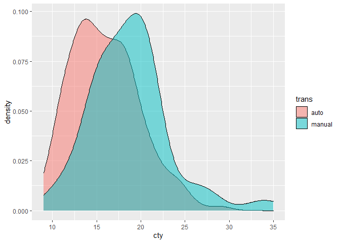

```r
ggplot(mpg1, aes(x=cty, fill=trans)) +
  geom_density(alpha=0.5)
```

### 교차분석

- 범주형 변수들이 관계가 있다는 것을 검정
- 비율에 차이가 있는지 검정
- r의 chisq.test() 함수로 진행
- ex)
  - 귀무가설 : trans에 따라 drv(4, f, r)의 (비율)차이가 없다.
  - 대립가설 : trans에 따라 drv의 차이가 있다.

```r
table(mpg1$trans, mpg1$drv) # 교차분석
```

```
##
##           4  f  r
##   auto   75 65 17
##   manual 28 41  8
```

```r
prop.table(table(mpg1$trans, mpg1$drv),1) # 비율 분석
```

```
##
##                  4         f         r
##   auto   0.4777070 0.4140127 0.1082803
##   manual 0.3636364 0.5324675 0.1038961
```

```r
chisq.test(mpg1$trans, mpg1$drv)
```

```
##
##  Pearson's Chi-squared test
##
## data:  mpg1$trans and mpg1$drv
## X-squared = 3.1368, df = 2, p-value = 0.2084
```

### 상관관계분석

- r 의 cor.test()함수로 진행
- cor값이 1에 가까울수록 높은 상관관계이다.
- cor : 상관계수
- ex)
  - 귀무가설 : cty와 hwy는 상관관계가 없다.
  - 대립가설 : cty와 hwy는 상관관계가 있다.

```r
cor.test(mpg1$cty, mpg1$hwy)
```

```
##
##  Pearson's product-moment correlation
##
## data:  mpg1$cty and mpg1$hwy
## t = 49.585, df = 232, p-value < 2.2e-16
## alternative hypothesis: true correlation is not equal to 0
## 95 percent confidence interval:
##  0.9433129 0.9657663
## sample estimates:
##       cor
## 0.9559159
```

```r
 # p의 값이 0.05보다 낮으니 대립가설이다
 # r=96
```